# Reproducible Research - Peer Assessment 2

09/18/2015

# Analysis of NOAA Storm Database

Access, data-wrangle, and provide data visualization of key variables contained in the NOAA Storm Database.

# Synopsis of Analysis

The basic goal of this assignment is to explore the NOAA Storm Database and answer some basic questions about severe weather events. The questions are the following:

1. Across the United States, which types of events (as indicated in the `EVTYPE` variable) are most harmful with respect to population health?
2. Across the United States, which types of events have the greatest economic consequences?

The approach used in the analysis of this dataset is:

1. Obtain the data from the National Weather Service (NWS) website
2. Massage/data-wrangle the dataset into dataframes which provide a focused set of data elements necessary to answer the questions
3. Perform summary calculations on the reduced datasets
4. Plot the data against all known event types
5. Provide interpretation of the results
6. Summarize the findings

# Abstract

Storms and other severe weather events can cause both public health and economic problems for communities and municipalities. Many severe events can result in fatalities, injuries, and property damage, and preventing such outcomes to the extent possible is a key concern.

# Data Processing

The data for this assignment come in the form of a comma-separated-value file compressed via the bzip2 algorithm to reduce its size. You can download the file from this link: [Storm Data](https://d396qusza40orc.cloudfront.net/repdata%2Fdata%2FStormData.csv.bz2)

There is also some documentation of the database available. Here you will find how some of the variables are constructed/defined.

[National Weather Service Storm Data Documentation](https://d396qusza40orc.cloudfront.net/repdata%2Fpeer2_doc%2Fpd01016005curr.pdf)

[National Climatic Data Center Storm Events FAQ](https://d396qusza40orc.cloudfront.net/repdata%2Fpeer2_doc%2FNCDC%20Storm%20Events-FAQ%20Page.pdf)

The events in the database start in the year 1950 and end in November 2011. In the earlier years of the database there are generally fewer events recorded, most likely due to a lack of good records. More recent years should be considered more complete.

Once the data file has been downloaded, it can be loaded into **R** using the following function call:

```r
stormData <- read.csv(bzfile("./data/repdata_data_StormData.csv.bz2"), stringsAsFactors = FALSE)
```

A quick display of the dataframe’s variables will help in subsequent selection and filtering approaches:

```r
str(stormData)
```

```
## 'data.frame':    902297 obs. of  37 variables:
##  $ STATE__   : num  1 1 1 1 1 1 1 1 1 1 ...
##  $ BGN_DATE  : chr  "4/18/1950 0:00:00" "4/18/1950 0:00:00" "2/20/1951 0:00:00" "6/8/1951 0:00:00" ...
##  $ BGN_TIME  : chr  "0130" "0145" "1600" "0900" ...
##  $ TIME_ZONE : chr  "CST" "CST" "CST" "CST" ...
##  $ COUNTY    : num  97 3 57 89 43 77 9 123 125 57 ...
##  $ COUNTYNAME: chr  "MOBILE" "BALDWIN" "FAYETTE" "MADISON" ...
##  $ STATE     : chr  "AL" "AL" "AL" "AL" ...
##  $ EVTYPE    : chr  "TORNADO" "TORNADO" "TORNADO" "TORNADO" ...
##  $ BGN_RANGE : num  0 0 0 0 0 0 0 0 0 0 ...
##  $ BGN_AZI   : chr  "" "" "" "" ...
##  $ BGN_LOCATI: chr  "" "" "" "" ...
##  $ END_DATE  : chr  "" "" "" "" ...
##  $ END_TIME  : chr  "" "" "" "" ...
##  $ COUNTY_END: num  0 0 0 0 0 0 0 0 0 0 ...
```

[output cut: 23 more lines]

There are 37 variables in this dataset, and only a small subset of those are needed for this analysis. So, load the `dplyr` package in order to use its elegant selection and filtering capabilities.

```r
suppressMessages(library(dplyr))
library("dplyr")
```

For the public health question, the **FATALITIES** and **INJURIES** columns would be of significance and for the economic question, the **PROPDMG**, **PROPDMGEXP**, **CROPDMG**, and **CROPDMGEXP** columns will contain useful information. Naturally, the **EVTYPE** column will be included, since it is the categorical variable against which our other data points will be measured.

```r
stormData  <- stormData  %>% select(c(EVTYPE, FATALITIES, INJURIES, PROPDMG, PROPDMGEXP, CROPDMG, CROPDMGEXP))
```

```r
populationData <-   stormData  %>%
                    select(c(EVTYPE, FATALITIES, INJURIES)) %>%
                    filter(FATALITIES > 0.00 & INJURIES > 0.00)
```

```r
economicData <-   stormData  %>%
                  select(c(EVTYPE, PROPDMG, PROPDMGEXP, CROPDMG, CROPDMGEXP)) %>%
                  filter(PROPDMG > 0.00 & CROPDMG > 0.00)
```

This leaves 2649 rows for the dataset used to answer the population question and 16242 rows to answer the economic question, a significant reduction from the 902297 rows of the original dataset. But, can the datasets be reduced even further? If we run `summary` against columns of interest in each dataset, we may get some guidance.

```r
summary(populationData$FATALITIES)
```

```
##    Min. 1st Qu.  Median    Mean 3rd Qu.    Max.
##   1.000   1.000   1.000   2.862   2.000 158.000
```

```r
summary(populationData$INJURIES)
```

```
##    Min. 1st Qu.  Median    Mean 3rd Qu.    Max.
##    1.00    2.00    5.00   29.82   20.00 1700.00
```

Looking at these results, the significant values appear in the 3rd quartile. Using that information, let’s filter the population dataset down a bit more:

```r
populationData  <- populationData  %>% filter(FATALITIES >= 2 & INJURIES >= 20)
```

Appying the same approach to the economic data, we have the following summary information:

```r
summary(economicData$PROPDMG)
```

```
##    Min. 1st Qu.  Median    Mean 3rd Qu.    Max.
##    0.01    5.00   15.00   66.23   50.00  975.00
```

```r
summary(economicData$CROPDMG)
```

```
##    Min. 1st Qu.  Median    Mean 3rd Qu.    Max.
##    0.01    5.00   10.00   64.76   50.00  978.00
```

Again, it appears that the dataset can be further reduced by using the values for the 3rd quartile, and so we apply that filter now:

```r
economicData  <- economicData  %>% filter(PROPDMG >= 50 & CROPDMG >= 50)
```

The next step in the processing is to reverse-map the 48 Event Types defined by the NWS to the entries in our datasets. The complete list can be found in the link to the NWS Storm Data Documentation given above and is reproduced here for completeness.

| Event Type | Event Type | Event Type | Event Type |
| --- | --- | --- | --- |
| Astronomical Low Tide | Extreme Cold/Wind Chill | Hurricane (Typhoon) | Storm Surge/Tide |
| Avalanche | Flash Flood | Ice Storm | Strong Wind |
| Blizzard | Flood | Lake-Effect Snow | Thunderstorm Wind |
| Coastal Flood | Frost/Freeze | Lakeshore Flood | Tornado |
| Cold/Wind Chill | Funnel Cloud | Lightning | Tropical Depression |
| Debris Flow | Freezing Fog | Marine Hail | Tropical Storm |
| Dense Fog | Hail | Marine High Wind | Tsunami |
| Dense Smoke | Heat | Marine Strong Wind | Volcanic Ash |
| Drought | Heavy Rain | Marine Thunderstorm Wind | Waterspout |
| Dust Devil | Heavy Snow | Rip Current | Wildfire |
| Dust Storm | High Surf | Seiche | Winter Storm |
| Excessive Heat | High Wind | Sleet | Winter Weather |

Some of the `EVTYPE` values found in our dataset are 1::1 with the NWS types but for those which are not, the following process will normalize them. First, for the population data:

**Note**: This [link](http://forecast.weather.gov/glossary.php?word=tstm) will give the definition for **TSTM**, i.e., thunderstorm, as justification for changing any `EVTYPE` entries with that value to one of Thunderstorm.

```r
cold  <- grepl("cold", populationData$EVTYPE, ignore.case = T)
populationData$EVTYPE[cold]  <- "Cold/Wind Chill"

rain  <- grepl("rain", populationData$EVTYPE, ignore.case = T)
populationData$EVTYPE[rain]  <- "Heavy Rain"

fog  <- grepl("fog", populationData$EVTYPE, ignore.case = T)
populationData$EVTYPE[fog]  <- "Dense Fog"

heat  <- grepl("heat wave", populationData$EVTYPE, ignore.case = T)
populationData$EVTYPE[heat]  <- "Excessive Heat"

wind  <- grepl("high wind", populationData$EVTYPE, ignore.case = T)
populationData$EVTYPE[wind]  <- "High Wind"

tropical  <- grepl("tropical storm", populationData$EVTYPE, ignore.case = T)
populationData$EVTYPE[tropical]  <- "Tropical Storm"

thunder  <- grepl("tstm", populationData$EVTYPE, ignore.case = T)
populationData$EVTYPE[thunder]  <- "THUNDERSTORM WIND"

stream  <- grepl("urban", populationData$EVTYPE, ignore.case = T)
populationData$EVTYPE[stream]  <- "Flash Flood"

fire  <- grepl("fire", populationData$EVTYPE, ignore.case = T)
populationData$EVTYPE[fire]  <- "Wildfire"

hurricane  <- grepl("hurricane", populationData$EVTYPE, ignore.case = T)
populationData$EVTYPE[hurricane]  <- "Hurricane (Typhoon)"

spout  <- grepl("waterspout", populationData$EVTYPE, ignore.case = T)
populationData$EVTYPE[spout]  <- "Waterspout"
```

Next, for the economic data:

```r
dust  <- grepl("dust", economicData$EVTYPE, ignore.case = T)
economicData$EVTYPE[dust] <- "Dust Storm"

cold <- grepl("extreme cold", economicData$EVTYPE, ignore.case = T)
economicData$EVTYPE[cold] <- "Extreme Cold/Wind Chill"

flash <- grepl("flash", economicData$EVTYPE, ignore.case = T)
economicData$EVTYPE[flash] <- "Flash Flood"

FLOOD <- grepl("FL.*D", economicData$EVTYPE, ignore.case = F)
economicData$EVTYPE[FLOOD] <- "Flood"

freeze <- grepl("freeze", economicData$EVTYPE, ignore.case = T)
economicData$EVTYPE[freeze] <- "Frost/Freeze"

gust <- grepl("gusty", economicData$EVTYPE, ignore.case = T)
economicData$EVTYPE[gust] <- "High Wind"

hail <- grepl("hail", economicData$EVTYPE, ignore.case = T)
economicData$EVTYPE[hail] <- "Hail"

heat <- grepl("heat", economicData$EVTYPE, ignore.case = T)
economicData$EVTYPE[heat] <- "Heat"

storm <- grepl("typhoon", economicData$EVTYPE, ignore.case = T)
economicData$EVTYPE[storm] <- "Tropical Storm"

rain <- grepl("rain", economicData$EVTYPE, ignore.case = T)
economicData$EVTYPE[rain] <- "Heavy Rain"

hurricane <- grepl("hurricane", economicData$EVTYPE, ignore.case = T)
economicData$EVTYPE[hurricane] <- "Hurricane (Typhoon)"

thunder <- grepl("thu.*s.*", economicData$EVTYPE, ignore.case = T)
economicData$EVTYPE[thunder] <- "Thunderstorm Wind"

tstm <- grepl("tstm", economicData$EVTYPE, ignore.case = T)
economicData$EVTYPE[tstm] <- "Thunderstorm Wind"

tropical <- grepl("tropical", economicData$EVTYPE, ignore.case = T)
economicData$EVTYPE[tropical] <- "Tropical Storm"

wildfire <- grepl("wildfire", economicData$EVTYPE, ignore.case = T)
economicData$EVTYPE[wildfire] <- "Wildfire"

forest <- grepl("forest", economicData$EVTYPE, ignore.case = T)
economicData$EVTYPE[forest] <- "Wildfire"

winter  <- grepl("winter", economicData$EVTYPE, ignore.case = T)
economicData$EVTYPE[winter] <- "Winter Storm"
```

A little more cleanup:

1. make the `EVTYPE` values all free of extraneous whitespace and in upper case
2. make `EVTYPE` a factor variable now so its values can be used in later graphs

```r
populationData$EVTYPE  <- toupper(trimws(populationData$EVTYPE))
populationData$EVTYPE  <- as.factor(populationData$EVTYPE)

economicData$EVTYPE <- toupper(trimws(economicData$EVTYPE))
economicData$EVTYPE  <- as.factor(economicData$EVTYPE)
```

As the final step in the cleanup, we need to examine the multiplier column for economic data. The `PROPDMGEXP` and `CROPDMGEXP` can have a wide range of values ([see here](https://rstudio-pubs-static.s3.amazonaws.com/58957_37b6723ee52b455990e149edde45e5b6.html) for more information), many of which may have been already culled out as a result of the data-wrangling process. Let’s see what’s left:

```r
unique(economicData$PROPDMGEXP)
```

```
## [1] "K" "M"
```

```r
unique(economicData$CROPDMGEXP)
```

```
## [1] "K" "M" "0" "k"
```

So for the `PROPDMGEXP` we have just multipliers for thousands and millions of dollars; the `CROPDMGEXP` needs a bit more cleanup. First, we’ll remove the **0** multiplier, since it is not a contributor to the overall damage costs, then we’ll normalize the **k** value to be consistent with the other `CROPDMGEXP` values.

```r
economicData <- economicData %>% filter(CROPDMGEXP != 0)
economicData$CROPDMGEXP <- toupper(economicData$CROPDMGEXP)
```

Now we can start summarizing the data and arriving at some results.

# Results

Once the data has been processed into a format suitable for analysis, we can summarize the totals for fatalities and injuries based on each distinct `EVTYPE`.

```r
populationTotals <- populationData %>%
                    group_by(EVTYPE) %>%
                    summarise(fatalities = sum(FATALITIES), injuries = sum(INJURIES))
```

Plotting both fatalities and injuries across all `EVTYPE` values will provide a clear picture of which `EVTYPE` had the most impact on human life.

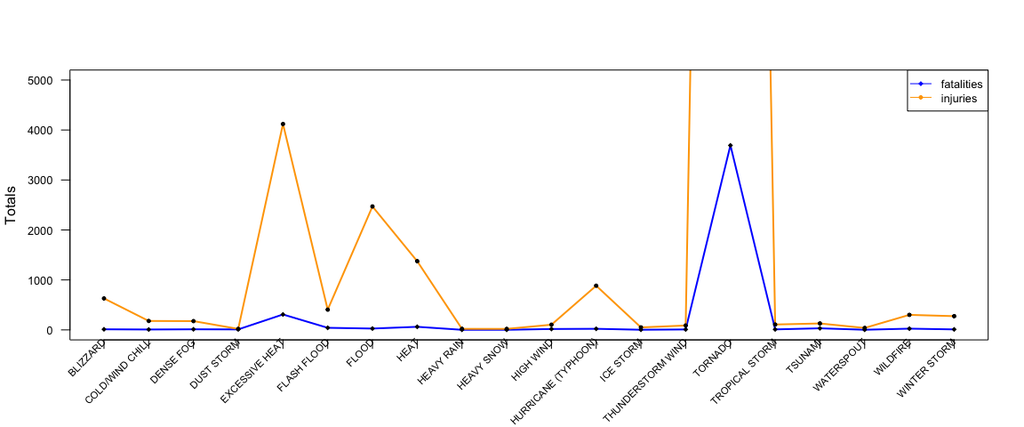

Figure 1: Summary of fatalities and injuries by Event Type

```r
plot(populationTotals$fatalities,
     type="l",
     col="blue",
     axes=F,
     ann=T,
     xlab="",
     ylab="Totals",
     lwd=2,
     ylim=c(0, 5000))
axis(1,
     at=1:20,
     labels = F)
axis(2,
     las=1,
     cex.axis=0.8)
text(1:20,
     par("usr")[3] - 2,
     srt=45,
     adj=1,
     labels=populationTotals$EVTYPE,
     xpd=T,
     cex=0.7)
lines(populationTotals$injuries,
      col="orange",
      lwd=2)
points(populationTotals$fatalities, pch=18, cex=0.8)
points(populationTotals$injuries, pch=20, cex=0.8)
legend("topright",
      c("fatalities","injuries"),
      cex=0.8,
      col=c("blue","orange"),
      lty=1,
      pch=c(18, 20))
box()
```

From this graphic, it is overwhelmingly clear that **tornadoes** claimed more lives and caused more injuries than any other severe weather event, followed by **excessive heat** and **floods**.

Now we examine the question of which event cost the most in terms of property and crop damage. To do that, we use the multiplier (found in the variables *PROPDMGEXP* and *CROPDMGEXP*) associated with each indicator. Because of previous data-wrangling, at this point we know that we have multipliers for thousands and millions of dollars. That enables us to use the following code to calculate property damage costs for each observation, added as a new column to our dataset:

```r
economicData$PROPDMGCOST <-
  ifelse(economicData$PROPDMGEXP == "K",
         economicData$PROPDMG * 1.0e+03,
         economicData$PROPDMG * 1.0e+06)
```

Crop damage costs are calculated similarly:

```r
economicData$CROPDMGCOST <-
  ifelse(economicData$CROPDMGEXP == "K",
         economicData$CROPDMG * 1.0e+03,
         economicData$CROPDMG * 1.0e+06)
```

A bit more (minor) cleanup: we need only the `EVTYPE` and calculated columns now, so select only those:

```r
economicData <- economicData %>%
                select(c(EVTYPE, PROPDMGCOST, CROPDMGCOST))
```

The dataset is now in a reduced format, ready for summing. A new dataset is created, grouped by `EVTYPE` and with columns for total property and crop damage costs:

```r
economicCosts <-  economicData %>%
                  group_by(EVTYPE) %>%
                  summarise(propertyCosts = sum(PROPDMGCOST), cropCosts = sum(CROPDMGCOST))
```

Plotting the total property costs data will give the following graphic:

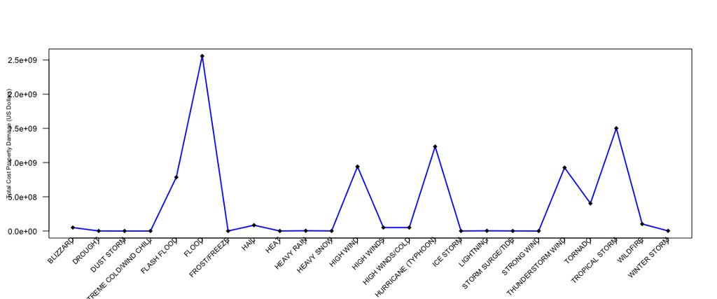

Figure 2: Property Damage Costs by Event Type

```r
plot(economicCosts$propertyCosts,
     type="l",
     col="blue",
     axes=F,
     ann=T,
     xlab="",
     ylab="Total Cost Property Damage (US Dollars)",
     cex.lab=0.6,
     lwd=2)
axis(1,
     at=1:nrow(economicCosts),
     labels = F)
axis(2,
     las=1,
     cex.axis=0.8)
text(1:nrow(economicCosts),
     par("usr")[3] - 2,
     srt=45,
     adj=1,
     labels=economicCosts$EVTYPE,
     xpd=T,
     cex=0.7)
points(economicCosts$propertyCosts, pch=18)
box()
```

Here, the major contributor to property damage is **Floods**, at about $2.5B US Dollars. That greatly exceeds the two nearest events, **Tropical Storms**, at $1.5B, and **Hurricane (Typhoon)**, at approximately $1.3B.

Taking a look at crop damage costs:

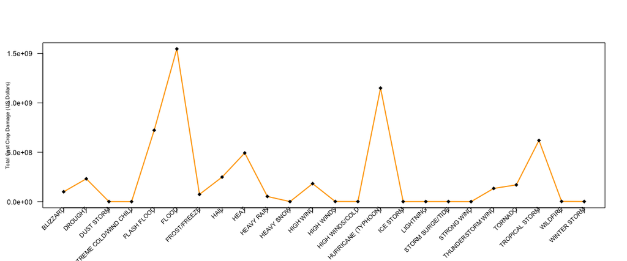

Figure 3: Crop Damage Costs by Event Type

```r
plot(economicCosts$cropCosts,
     type="l",
     col="orange",
     axes=F,
     ann=T,
     xlab="",
     ylab="Total Cost Crop Damage (US Dollars)",
     cex.lab=0.6,
     lwd=2)
axis(1,
     at=1:nrow(economicCosts),
     labels = F)
axis(2,
     las=1,
     cex.axis=0.8)
text(1:nrow(economicCosts),
     par("usr")[3] - 2,
     srt=45,
     adj=1,
     labels=economicCosts$EVTYPE,
     xpd=T,
     cex=0.7)
points(economicCosts$cropCosts, pch=18)
box()
```

# Summary

To summarize, then, let’s combine our original questions with our findings as a result of our analysis.

**Q1**. Across the United States, which types of events (as indicated in the `EVTYPE` variable) are most harmful with respect to population health?

**A1**. It was determined that the events which caused the most fatalities and injuries were, in order of decreasing impact, tornadoes, excessive heat, and flooding.

**Q2**. Across the United States, which types of events have the greatest economic consequences?